# Usage Analytics on Ford GoBike Sharing System

## by Uchenna Urom

## Investigation Overview

The goal of the investigation in this project was to analyse and identify key features affecting usage in the Ford GoBike Sharing system in the greater San Fransisco Bay Area in February 2019. Some major determining features included the Usertype, the day of the week and hour of day.

## Dataset Overview

The data is a csv excel spreadsheet containing 174, 952 recorded bike rides to and from different stations. There are 9 variables describing the features of the each ride. Some of the variables are the user-type, date and time of each ride, start and end station names, bike id and user gender.

The dataset was also divided into two tables to conform with tidiness standards. The `trip_df` table containing information on the each trip taken by a user. Also, the `user_df` table carries information about the user on each trip. 8, 460 rows were dropped from the original datset due to missing values.

## Distribution of Bike Ride Durations

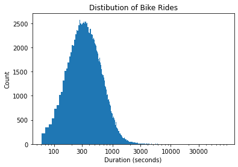

## Population of Users by Type

There were two categories of users - **Subscribers** and **Customers**. Subscribers exceeded the Customer category by a very large extent.

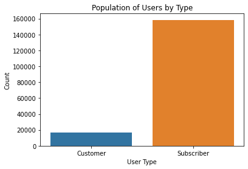

## User Population by Gender

Three gender groups were recorded - Male, Female, and Other. The Male gender group was evidently greater than the other two.

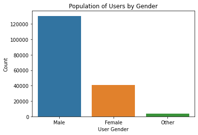

## Gender Distribution Among Users

The male gender had the most population of users among all the genders. THe Subscriber user type which was more common than the Customer type remained so for all gender groups.

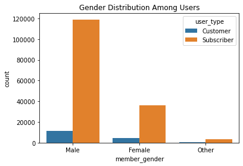

## Mean Trip Duration by User type

Customers took longer trips than Subscriber user type on average with almost a doubled score.

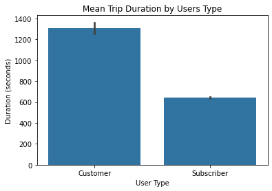

## Daily Bike Usage by User types

The Subscribers had more usage for the bikes on every day of the week. However, there was less demand on the weekends than on weekdays.

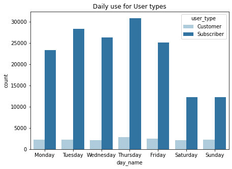

## Daily Bike Use by Time of Day Among Users

The peak hours during the weekdays were around the mornings (**7 to 10**) and evenings (**15 to 17**).

Whereas the weekend had a differnt pattern. More demand was seen between **10 and 15** on the weekends than any other hour.

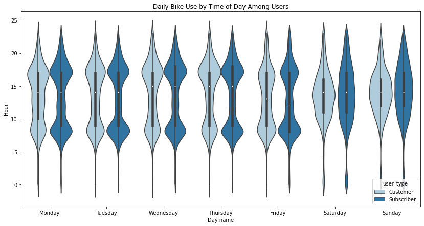